# ggplot2 exercise

Ram Thapa

June 22, 2022

**Packages and data**

```r
library(tidyverse)
library(patchwork)

tcga_clinical <- read_csv(here::here("data", "tcga-clinical-viz.csv"))

head(tcga_clinical)
```

| bcr_patient_barcode | acronym | tobacco_smoking_history | race | radiation_therapy | vital_status | age_at_initial_pathologic_diagnosis | gender | stage | weight | height | tumor_tissue_site | karnofsky_performance_score |
| --- | --- | --- | --- | --- | --- | --- | --- | --- | --- | --- | --- | --- |
| TCGA-2E-A9G8 | UCEC | NA | BLACK OR AFRICAN AMERICAN | YES | Alive | 59 | FEMALE | Stage III | 71 | 157 | Endometrial | NA |
| TCGA-2F-A9KO | BLCA | Current smoker | WHITE | NO | Dead | 63 | MALE | Stage IV | 65 | 173 | Bladder | 80 |
| TCGA-2F-A9KP | BLCA | Current reformed smoker for < or = 15 years | WHITE | NO | Dead | 66 | MALE | Stage IV | 130 | 186 | Bladder | 80 |
| TCGA-2F-A9KQ | BLCA | Lifelong Non-smoker | WHITE | NO | Alive | 69 | MALE | Stage III | 72 | 168 | Bladder | 90 |
| TCGA-2F-A9KR | BLCA | Current smoker | [Not Evaluated] | NO | Dead | 59 | FEMALE | Stage III | 80 | 176 | Bladder | 70 |
| TCGA-2F-A9KT | BLCA | Current smoker | WHITE | NO | Alive | 83 | MALE | Stage II | 80 | 180 | Bladder | 80 |

## Visualizing associations among two or more variables

### Scatterplot

Relationship between height vs weight

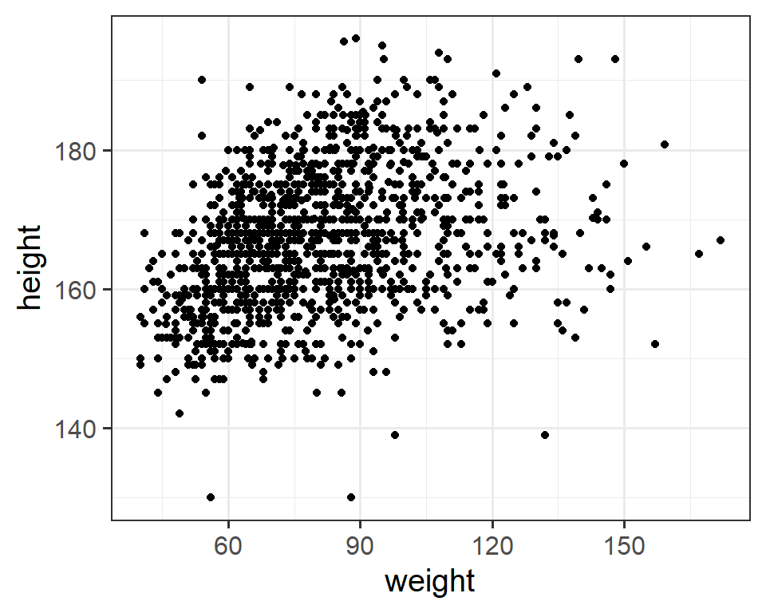

```r
# set theme to theme_bw()
theme_set(theme_bw(base_size = 15))

wt_ht_scatter <- ggplot(
  data = tcga_clinical,
  mapping = aes(x = weight, y = height)) +
  geom_point()

wt_ht_scatter
```

Mapping `color` to `gender` variable from the data

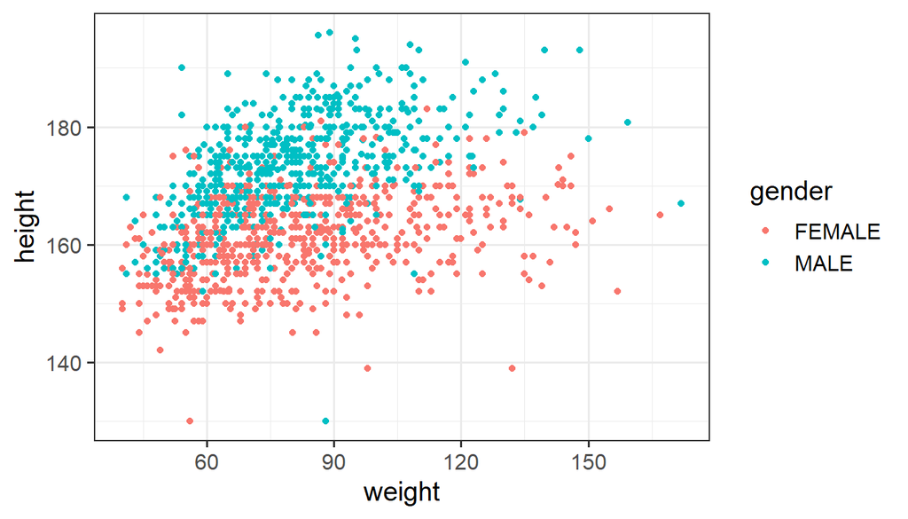

```r
wt_ht_scatter_gender <- ggplot(
  data = tcga_clinical,
  mapping = aes(x = weight, y = height, color = gender)) +
  geom_point()

wt_ht_scatter_gender
```

Avoid overplotting using jitter plot

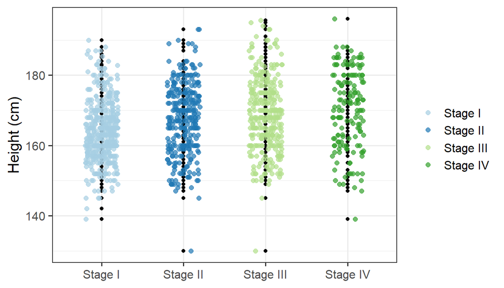

```r
tcga_clinical %>%
  ggplot(mapping = aes(x = stage, y = height)) +
  geom_point() +
  geom_jitter(aes(color = stage), width = 0.2, size = 2, alpha = 0.7) +
  labs(x = NULL, y = "Height (cm)") +
  scale_color_brewer(NULL, palette = "Paired")
```

Note: `geom_jitter` is a shortcut for `geom_point(position = "jitter")`

### Line plot

Line plot of mean age by Karnofsky Performance Score for each stage

```r
# mean age
mean_age_kps <- tcga_clinical %>%
  drop_na(stage, karnofsky_performance_score) %>%
  group_by(stage, karnofsky_performance_score) %>%
  summarise(mean_age = mean(age_at_initial_pathologic_diagnosis, na.rm = TRUE))
```

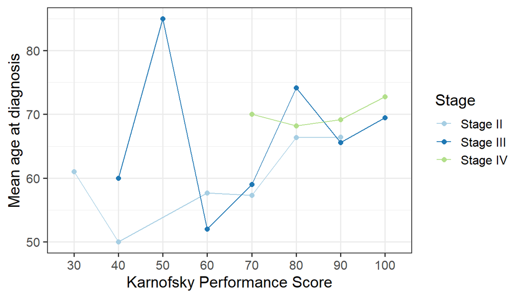

```r
# plot
mean_age_kps_line <- mean_age_kps %>%
  ggplot(aes(x = factor(karnofsky_performance_score), y = mean_age,
             group = stage, color = stage)) +
  geom_point(size = 2) +
  geom_line() +
  scale_x_discrete("Karnofsky Performance Score") +
  scale_y_continuous("Mean age at diagnosis") +
  scale_color_brewer("Stage", palette = "Paired")

mean_age_kps_line
```

## Visualizing amounts

We might be interested in visualizing amounts i.e. numerical values for some set of categories

### Bar plot

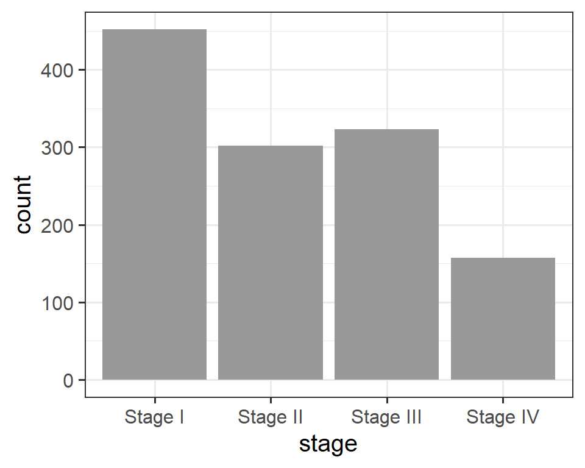

```r
tcga_clinical %>%
  ggplot(aes(x = stage)) +
  geom_bar(fill = "gray60")
```

You could also calculate counts in advance and plot it but you need to use `stat = "identity"`

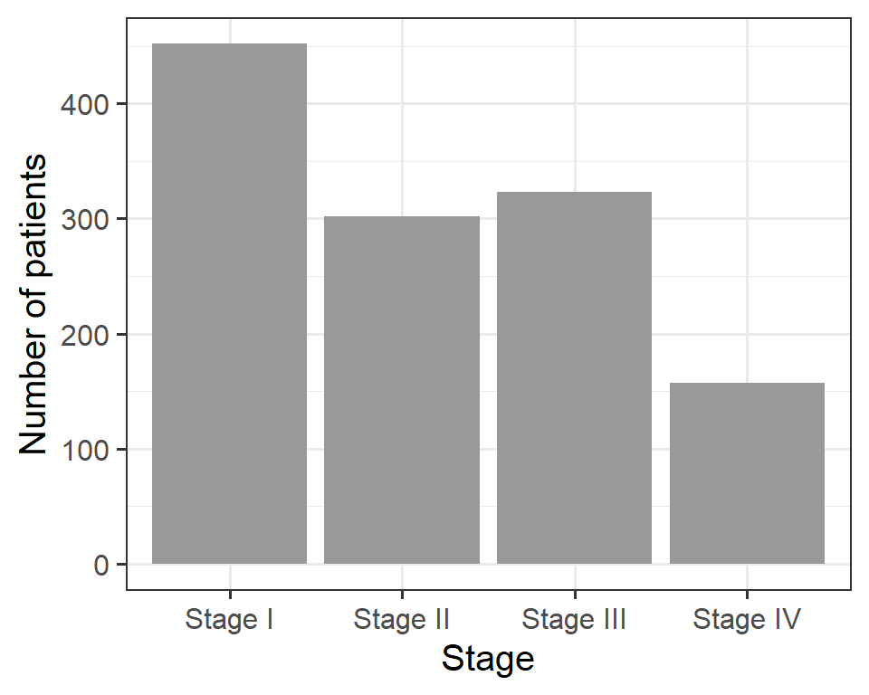

```r
# Count by stage
stage_count <- tcga_clinical %>%
  count(stage, .drop = TRUE)

# use stat = "identity"
ggplot(data = stage_count, aes(x = stage, y = n)) +
  geom_bar(stat = "identity", fill = "gray60") +
  labs(x = "Stage", y = "Number of patients")
```

Or, just use `geom_col()`

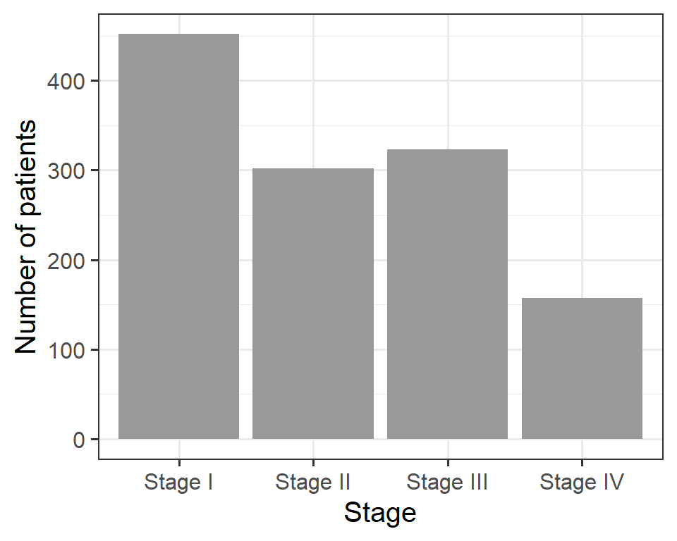

```r
ggplot(data = stage_count, aes(x = stage, y = n)) +
  geom_col(fill = "gray60") +
  labs(x = "Stage", y = "Number of patients")
```

Sometimes x-axis labels identifying each bar take up a lot of horizontal space

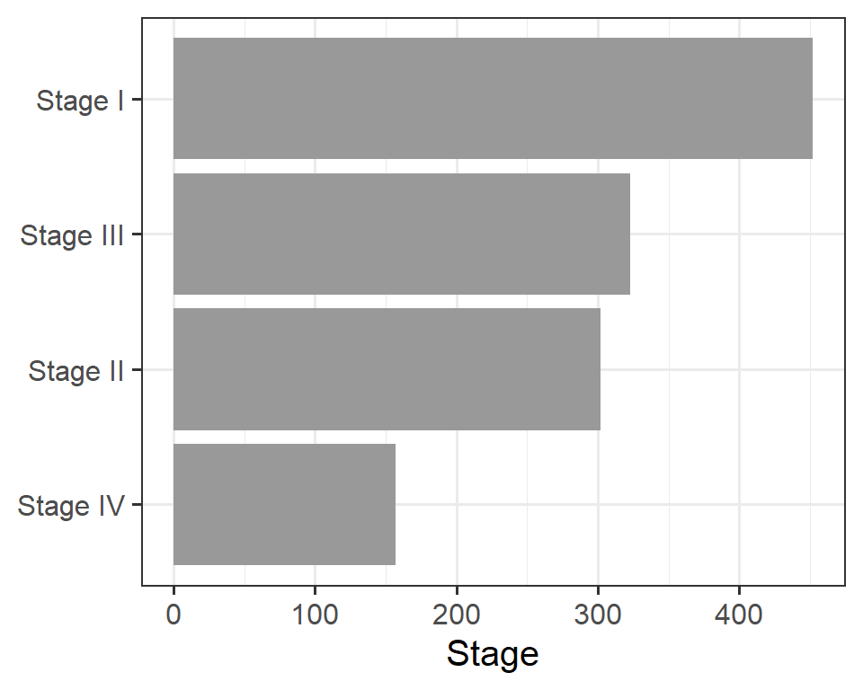

```r
ggplot(data = stage_count, aes(y = fct_reorder(stage, n), x = n)) +
  geom_bar(stat = "identity", fill = "gray60") +
  labs(x = "Stage", y = NULL)
```

Grouped bar plot

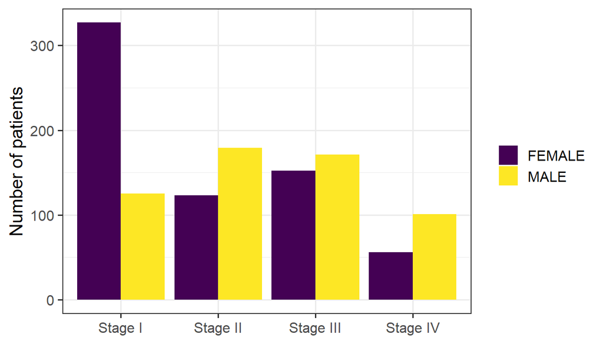

```r
groupedbar_gender <- tcga_clinical %>%
  ggplot(aes(x = stage, fill = gender)) +
  geom_bar(position = "dodge") +
  labs(x = NULL, y = "Number of patients") +
  scale_fill_viridis_d(NULL)

groupedbar_gender
```

Stacked bar plot

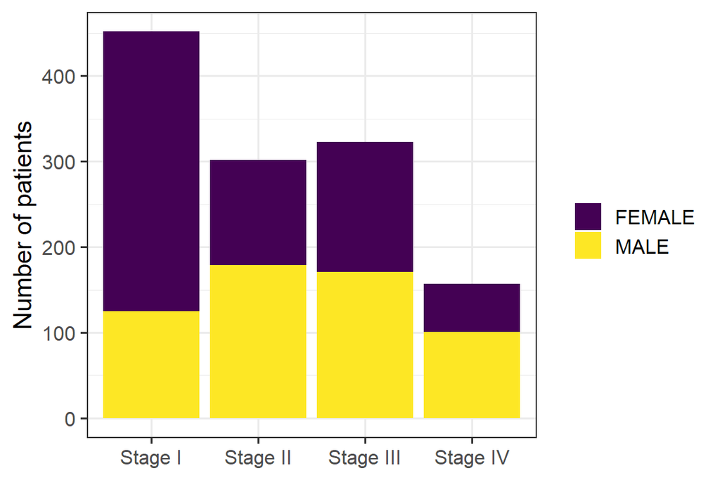

```r
stackedbar_gender <- tcga_clinical %>%
  ggplot(aes(x = stage, fill = gender)) +
  geom_bar(position = "stack") +
  labs(x = NULL, y = "Number of patients") +
  scale_fill_viridis_d(NULL)

stackedbar_gender
```

## Visualizing distributions

To understand how a particular variable is distributed in a dataset

### Boxplot

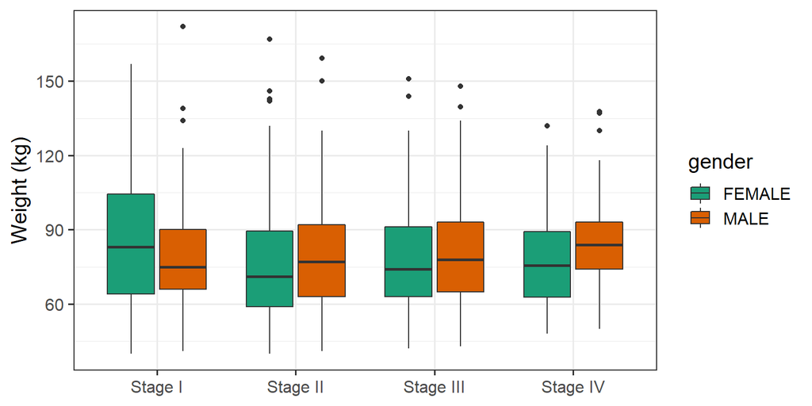

```r
boxplot_gender <- ggplot(
  data = tcga_clinical,
  aes(x = stage, y = weight, fill = gender)) +
  geom_boxplot() +
  labs(x = NULL, y = "Weight (kg)") +
  scale_fill_brewer(palette = "Dark2")

boxplot_gender
```

### histogram and density plot

Histogram count plot for single distribution

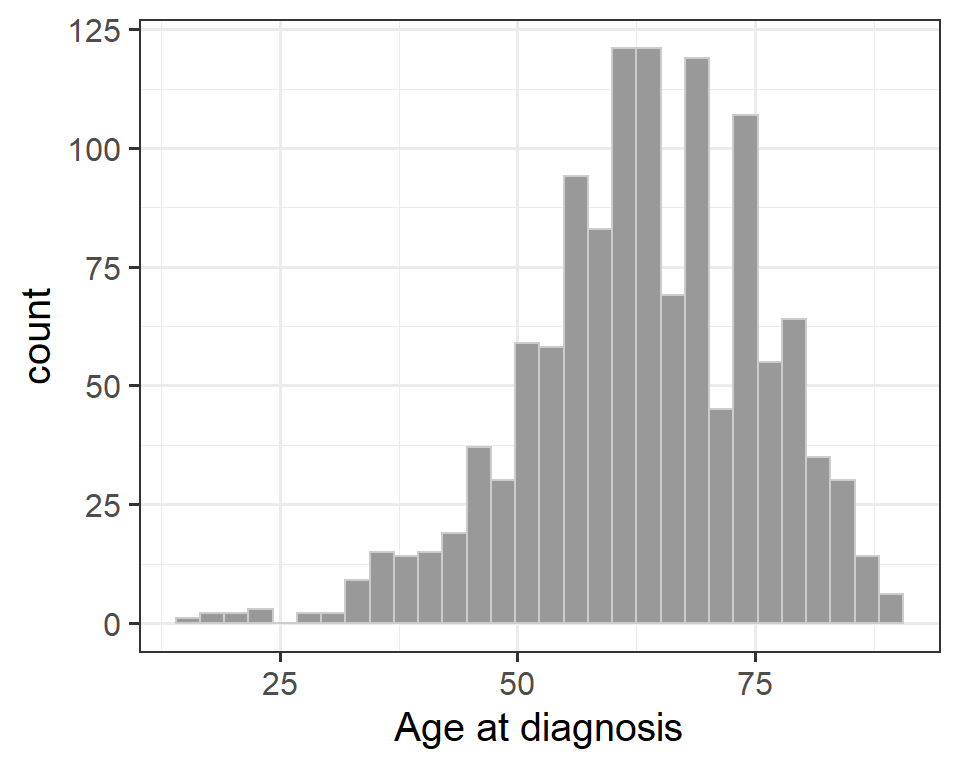

```r
hist_age <- ggplot(tcga_clinical, aes(x = age_at_initial_pathologic_diagnosis)) +
  geom_histogram(fill = "gray60", color = "gray80") +
  labs(x = "Age at diagnosis")

hist_age
```

Density plot for visualizing multiple distributions at the same time

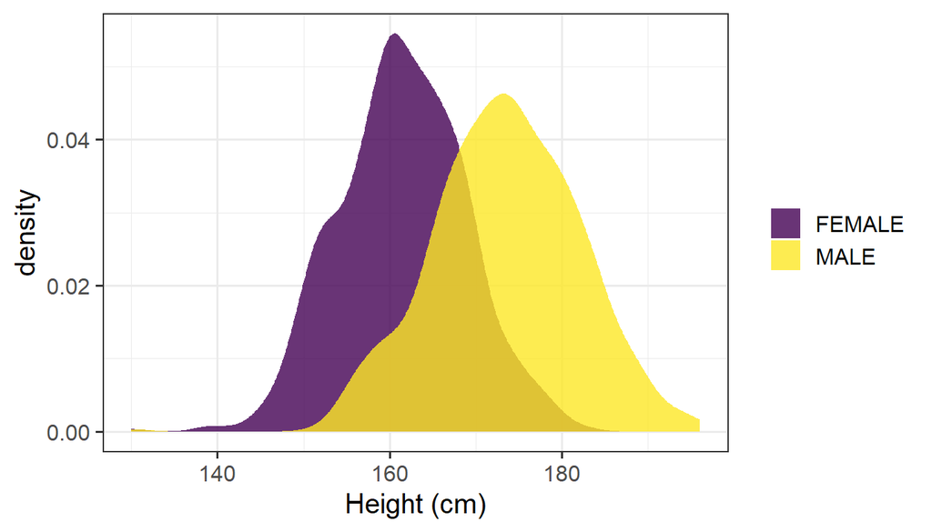

```r
ggplot(
  tcga_clinical,
  aes(x = height, fill = gender)) +
  geom_density(alpha = 0.8, color = "transparent") +
  labs(x = "Height (cm)") +
  scale_fill_viridis_d(NULL)
```

### Violin plot

Violin plot is the combination of the box plot with a kernel density plot.

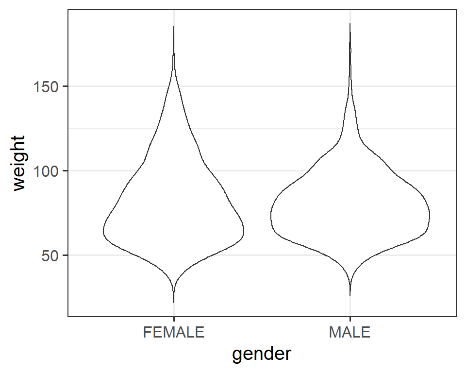

```r
wt_violin <- ggplot(
  tcga_clinical, aes(x = gender, y = weight)) +
  geom_violin(trim = FALSE)

wt_violin
```

Quantiles can be added the plot by passing a vector to the `draw_quantiles` argument

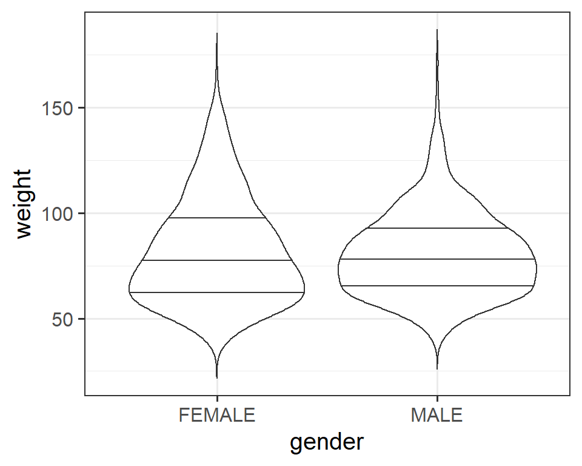

```r
# violin plot with quantile lines
ggplot(
  tcga_clinical, aes(x = gender, y = weight)) +
  geom_violin(trim = FALSE, draw_quantiles = c(0.25, 0.5, 0.75))
```

We can also overlay box plot to the violin plot

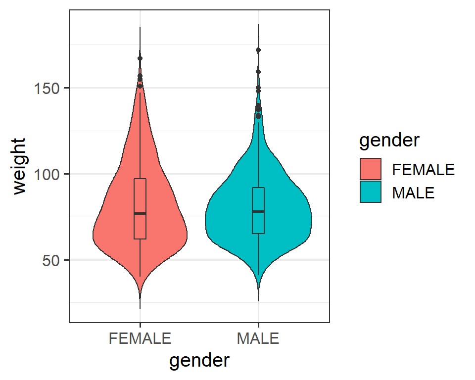

```r
wt_violin2 <- ggplot(
  tcga_clinical, aes(x = gender, y = weight, fill = gender)) +
  geom_violin(trim = FALSE) +
  geom_boxplot(width = 0.1, show.legend = FALSE)

wt_violin2
```

## Heatmaps

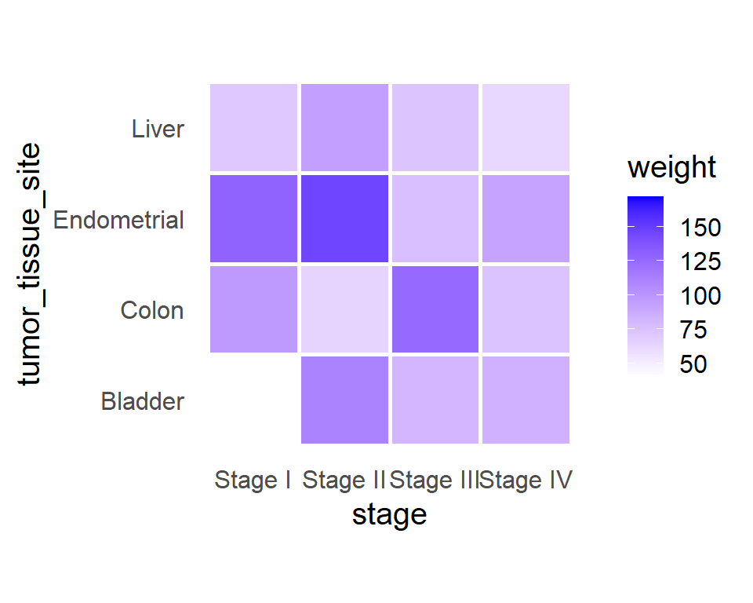

```r
wt_heatmap <- ggplot(tcga_clinical, aes(x = stage, y = tumor_tissue_site, fill = weight)) +
  geom_tile(
    color = "white", lwd = 1, linetype = 1) +
  scale_fill_gradient(
    low = "white", high = "blue", na.value = "red") +
  coord_fixed() +
  theme_minimal(base_size = 15) +
  theme(panel.grid = element_blank())

wt_heatmap
```

## Combining plots

`{patchwork}` R package has made combining multiple plots ridiculuous simple

### Horizontal layout

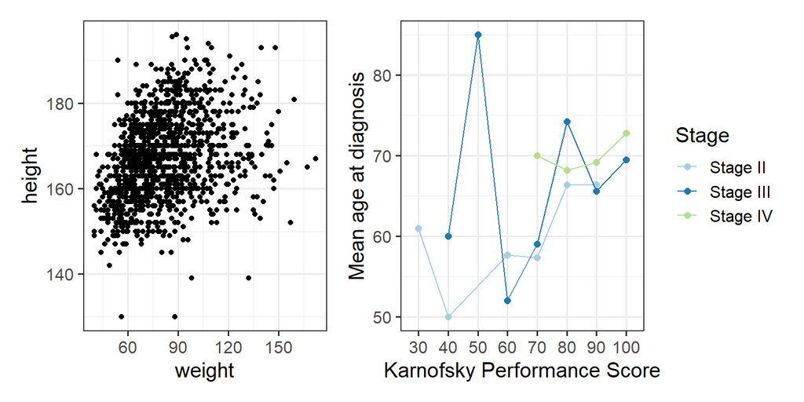

```r
# combine two plots horizontally
wt_ht_scatter + mean_age_kps_line
```

or you can use “|” too

### Vertical layout

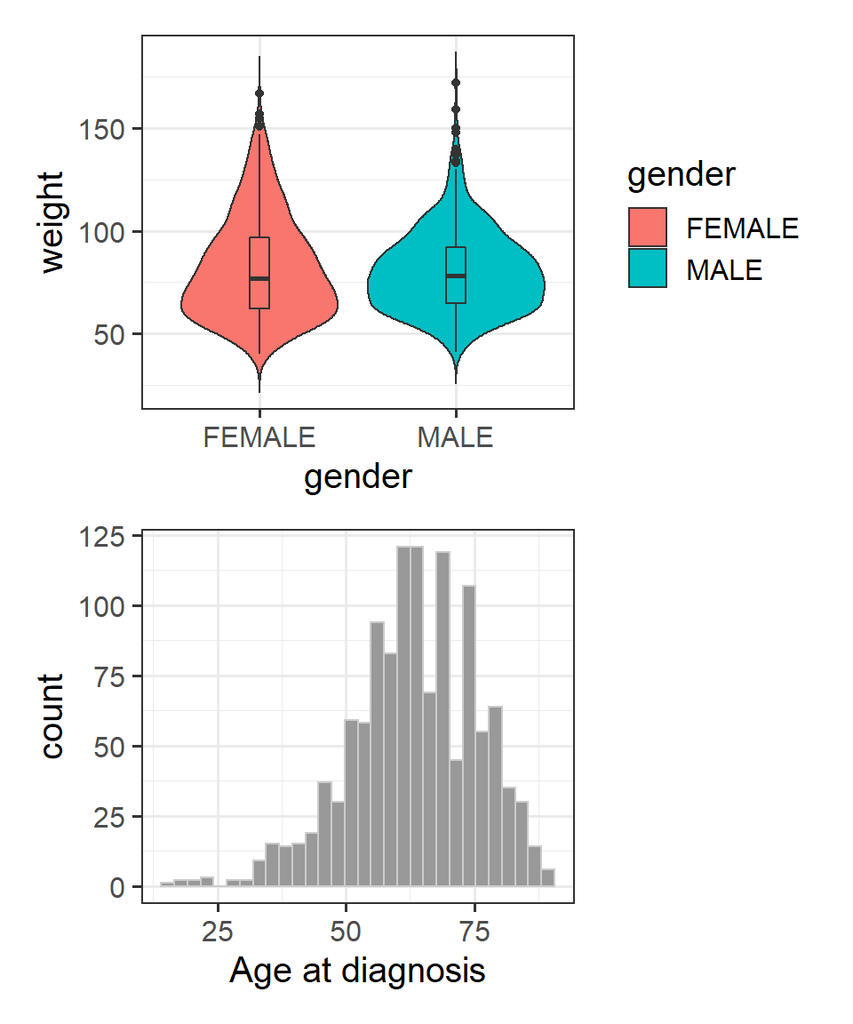

```r
# stack two plots
wt_violin2 / hist_age
```

### Nested layout

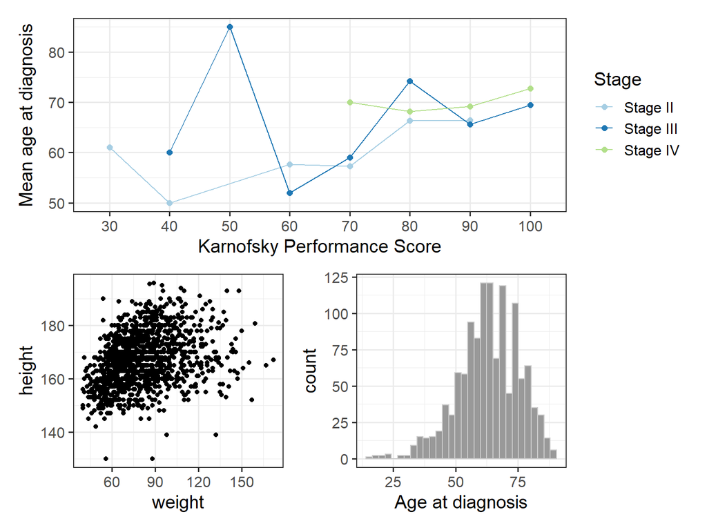

```r
nested_patch <- mean_age_kps_line / (wt_ht_scatter | hist_age)

nested_patch
```

Be careful with the operator precedence rule (e.g. / is evaluated before |)

`{patchwork}` provides `wrap_plots()` for a more functional approach to assembly

### Annotating plots

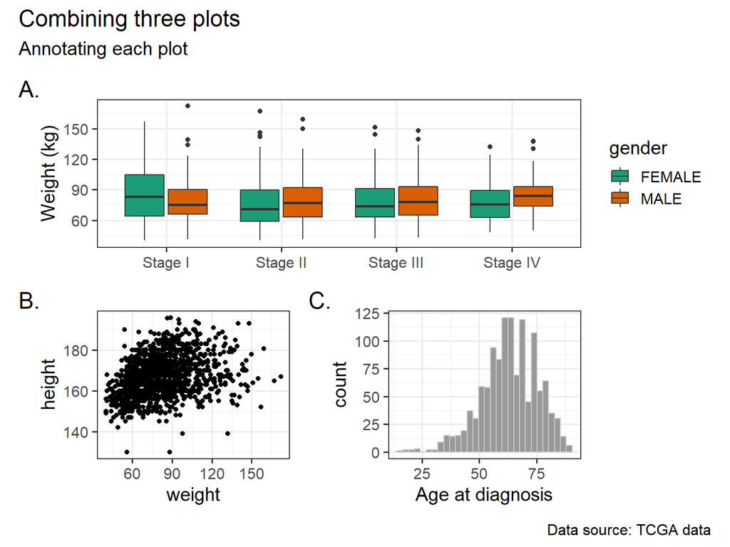

```r
(boxplot_gender / (wt_ht_scatter | hist_age)) +
  plot_annotation(
    title = "Combining three plots",
    subtitle = "Annotating each plot",
    caption = "Data source: TCGA data",
    tag_levels = "A", tag_suffix = ".")
```

### Modifying patches

Use `&` to add elements to all subplots in the patchwork

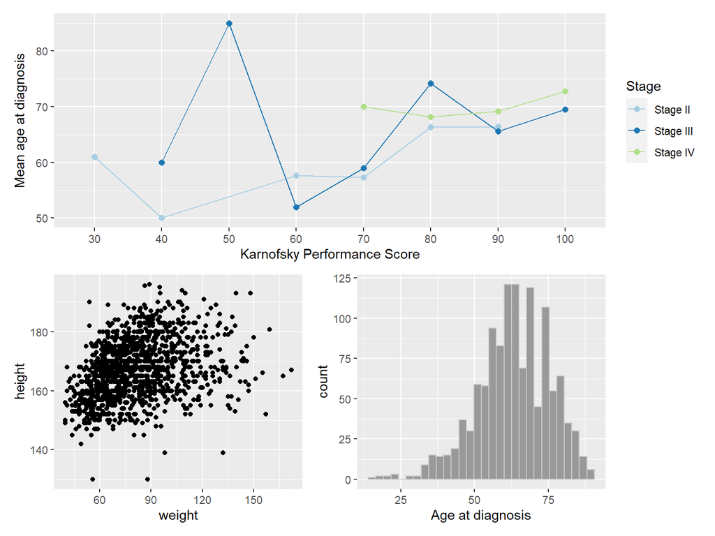

```r
mean_age_kps_line / (wt_ht_scatter | hist_age) & theme_gray()
```

and `*` to add the element to all the subplots in the current nesting level

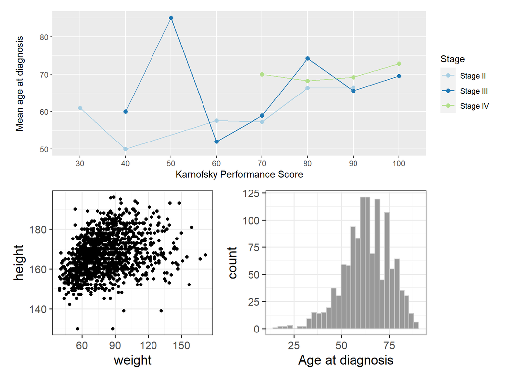

```r
(mean_age_kps_line / (wt_ht_scatter | hist_age)) * theme_gray()
```

### Controlling guides

If multiple plots have same guide, using `guides = "collect"` in `plot_layout()` drops the duplicate guide

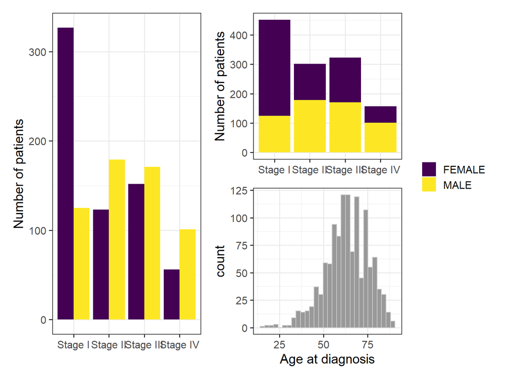

```r
(groupedbar_gender | (stackedbar_gender / hist_age)) +
  plot_layout(guides = "collect")
```